# ldacov - A new Latent Dirichlet Allocation (LDA) formulation with covariates

ldacov (Shimizu, Izbicki, and Valle (2020)) is an R package that estimates the Latent Dirichlet Allocation (LDA) model with covariates using an MCMC algorithm. The model implemented in this package uses the number of elements in each cluster as the response variable. The logarithmic link function used to relate covariates to the response variable allows an easy interpretation of the regression coefficients.

## Installation

Use the devtools package to install ldacov directly from github.

```
install_github("gilsonshimizu/ldacov")
```

The package can then be loaded using

```r
library(ldacov)
```

## Datasets

To run the LDA model with covariates, we need a counting matrix $y$ with dimension $l\times s$ ($l$ is the number of units, and $s$ the number of categories). In text analysis, for instance, $y$ is the bag-of-words matrix, where $l$ is the number of text documents and $s$ is the number of tokens (words). In Ecology, often $l$ is the number of field plots and $s$ is the number of species. We also need an matrix $X$ of dimension $l \times (d+1)$ with a column of 1’s for the intercept and the values for each of the $d$ covariates. Here we use a simulated data set which contains both matrices $y$ and $X$:

```r
data("sim_data")
```

## Optimal number of clusters

We start by finding the optimal number of clusters. Although this quantity could be chosen *a priori*, here we use an LDA model without covariates that relies on a truncated stick-breaking (TSB) prior to identify the number of clusters (Albuquerque, Valle, and Li (2019)). This model is implemented using the function `gibbs.LDA`. The arguments required for this function are:

- `y`: counting matrix containing the data (rows are units and columns are categories);
- `ncomm`: maximum number of clusters;
- `ngibbs`: number of iterations for the Gibbs sampler;
- `nburn`: number of iterations to be discarded as burn-in;
- `psi`: parameter for the prior Dirichlet distribution used for $\phi_k$ (the vector of probabilities that characterizes each cluster); and
- `gamma`: parameter for the TSB prior used for $\theta_l$ (the vector of probabilities that characterizes each unit).

```r
set.seed(1)
lda_no_covariates=gibbs.LDA(y=sim_data$y,
                            ncomm=10,
                            ngibbs=1000,
                            nburn=500,
                            psi=0.01,
                            gamma=0.1)
```

This function outputs a list which contains the following elements:

- `llk`: posterior samples for the log-likelihood;
- `theta`: posterior samples for the $\Theta$ matrix containing the proportion of each cluster in each unit;
- `phi`: posterior samples for the $\Phi$ matrix containing the proportion of each category within each cluster; and
- `vmat`: posterior samples for the $V$ matrix in the stick-breaking formulation, which is then used to derive the $\Theta$ matrix; and
- `array.lsk`: the last posterior sample for an array with the number of individuals in each unit, category, and cluster.

We first assess convergence by inspecting the trace-plot of the log-likelihood. This plot suggests that the algorithm has converged after discarding the first 500 iterations:

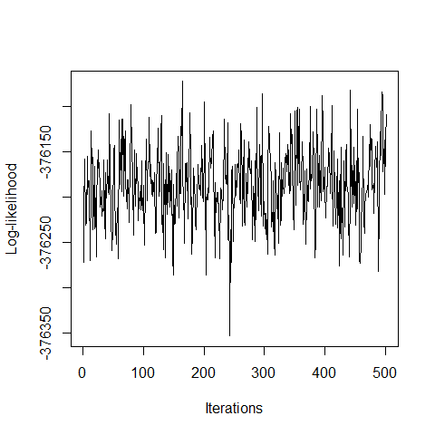

```r
plot(lda_no_covariates$llk,type='l',xlab='Iterations',ylab='Log-likelihood')
```

We used `array.lsk` to determine the optimal number of clusters (`theta` could have been used as well). On this dataset, the LDA model with the TSB prior seems to have identified 4 main cluster as these clusters contain more than 99% of the elements. Thus, we choose to use 4 clusters for the subsequent analysis.

```r
array.lsk.init=lda_no_covariates$array.lsk
nlk=apply(array.lsk.init,c(1,3),sum)
theta=nlk/apply(nlk,1,sum)
colnames(theta)=paste0('Cluster',1:10)
rownames(theta)=paste0('Unit',1:nrow(sim_data$y))
head(round(theta,2))
```

```
#>       Cluster1 Cluster2 Cluster3 Cluster4 Cluster5 Cluster6 Cluster7 Cluster8
#> Unit1     0.01     0.96     0.03     0.00     0.00        0        0        0
#> Unit2     0.01     0.00     0.00     0.98     0.01        0        0        0
#> Unit3     0.01     0.00     0.99     0.00     0.00        0        0        0
#> Unit4     1.00     0.00     0.00     0.00     0.00        0        0        0
#> Unit5     0.03     0.97     0.00     0.00     0.00        0        0        0
#> Unit6     0.00     0.00     0.00     1.00     0.00        0        0        0
#>       Cluster9 Cluster10
#> Unit1        0         0
#> Unit2        0         0
#> Unit3        0         0
#> Unit4        0         0
#> Unit5        0         0
#> Unit6        0         0
```

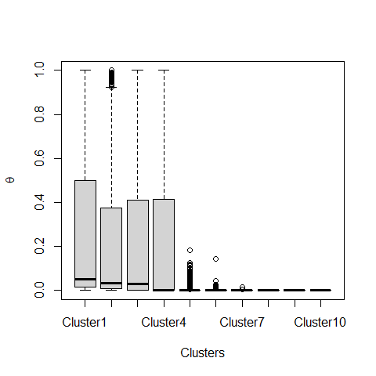

```r
boxplot(theta,ylab=expression(theta),xlab='Clusters',ylim=c(0,1))
```

```r
cumsum1=cumsum(colSums(theta,na.rm=TRUE)/nrow(sim_data$y))
cumsum1[1:4]
```

```
#>  Cluster1  Cluster2  Cluster3  Cluster4
#> 0.2808978 0.5194413 0.7637801 0.9953563
```

## Estimation

Once the number of clusters has been defined, the estimation of the parameters of ldacov are made through the function `gibbs.LDA.cov`. The arguments required by this function are:

- `ncomm`: number of clusters;
- `ngibbs`: number of iterations for the Gibbs sampler;
- `y`: counting matrix containing the data (rows are units and columns are categories);
- `xmat`: matrix containing covariate information (rows are units and each column contains a different covariate). Notice that the first column of this matrix should be comprised of 1’s if the regression model is to have an intercept;
- `phi.prior`: parameter to be used in the Dirichlet prior for $\Phi$ if this matrix is estimated;
- `array.lsk.init`: initial values for the `array.lsk` array;
- `var.betas`: variance parameters for the normal distribution priors for the regression coefficients;
- `phi.init`: posterior samples from the $\Phi$ matrix estimated by “gibbs.lda”. If `estimate.phi` is TRUE, then these posterior samples are used simply to initialize the $\Phi$ matrix. If `estimate.phi` is FALSE, then these posterior samples are used instead of attempting to re-estimate the $\Phi$ matrix; and
- `estimate.phi`: if $\Phi$ matrix is supposed to be estimated (TRUE or FALSE).

```r
lda_with_covariates <- gibbs.LDA.cov(ncomm=4,
                                     ngibbs=1000,
                                     y=sim_data$y,
                                     xmat=sim_data$xmat,
                                     phi.prior=0.01,
                                     array.lsk.init=lda_no_covariates$array.lsk,
                                     var.betas=rep(100,ncol(sim_data$xmat)),
                                     phi.init=lda_no_covariates$phi,
                                     estimate.phi=FALSE)
```

This function outputs a list which contains the following elements:

- `llk`: posterior samples for the log-likelihood;
- `phi`: if `estimate.phi`=TRUE, then this consists of posterior samples for the $\Phi$ matrix containing the proportion of each category within each cluster. If `estimate.phi`=FALSE, then this just outputs random samples from lda_no_covariates$phi;
- `nlk`: posterior samples for the $n_{lk}$ matrix containing the number of elements in each unit $l$ and cluster $k$;
- `betas`: posterior samples for the regression parameters for each cluster $k$; * `fmodel`: posterior samples of the log-likelihood plus the log priors; and
- `NBN`: posterior samples for the dispersion parameter $N$ from the negative-binomial regression.

One way to assess convergence consists of inspecting the trace-plot of the log-likelihood. This plot suggests that the algorithm has converged after discarding the first 100 iterations:

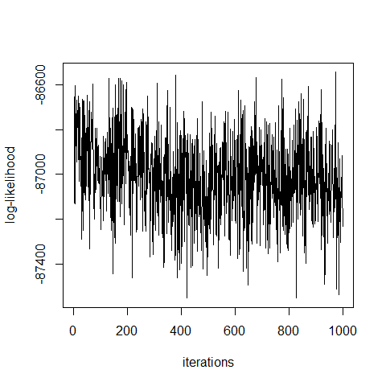

```r
plot(lda_with_covariates$llk,type='l',xlab="iterations",ylab='log-likelihood')
```

Typically, the main goals of the ldacov model are:

1. to verify which covariates explain the quantities in each cluster,
2. to understand the category distributions in each cluster (matrix $\Phi$),
3. and understand the distribution of the clusters within each unit (matrix $\Theta$).

We start by examining $\Theta$. We obtain the posterior mean for this matrix in the following way:

```r
seq1=100:1000
tmp=matrix(colMeans(lda_with_covariates$nlk[seq1,]),nrow=nrow(sim_data$y),ncol=4)
theta <- tmp/rowSums(tmp)
colnames(theta)=paste0('Cluster',1:4)
rownames(theta)=paste0('Units',1:nrow(sim_data$y))
head(round(theta,2))
```

```
#>        Cluster1 Cluster2 Cluster3 Cluster4
#> Units1     0.01     0.97     0.01     0.00
#> Units2     0.01     0.00     0.00     0.98
#> Units3     0.01     0.00     0.99     0.00
#> Units4     0.99     0.00     0.00     0.00
#> Units5     0.03     0.95     0.01     0.01
#> Units6     0.00     0.00     0.00     0.99
```

We then plot this matrix:

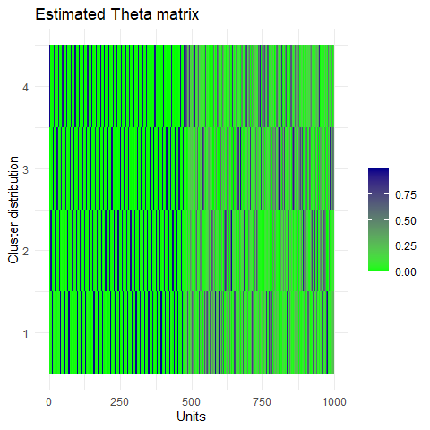

```r
data <- expand.grid(X=1:nrow(sim_data$y), Y=1:4)
data$proportion <- as.vector(theta)

library(ggplot2)
ggplot(data, aes(X, Y, fill= proportion)) + geom_tile() +
  scale_fill_gradient(low="green", high="darkblue",na.value="green") +
  labs(x = "Units") + labs(y = "Cluster distribution") +
  labs(fill = " ")+theme_minimal() +
  ggtitle("Estimated Theta matrix")
```

Similarly, we can also examine the $\Phi$ matrix. We calculate the posterior mean in the following way:

```r
phi <- matrix(colMeans(lda_with_covariates$phi[seq1,]),nrow=4,ncol=ncol(sim_data$y))
rownames(phi)=paste0('Cluster',1:4)
colnames(phi)=paste0('Category',1:ncol(sim_data$y))
head(round(phi[,1:10],2))
```

```
#>          Category1 Category2 Category3 Category4 Category5 Category6 Category7
#> Cluster1      0.00      0.00      0.04      0.00      0.04      0.00      0.00
#> Cluster2      0.04      0.00      0.00      0.00      0.00      0.04      0.00
#> Cluster3      0.00      0.00      0.00      0.04      0.00      0.00      0.00
#> Cluster4      0.00      0.03      0.00      0.00      0.00      0.00      0.03
#>          Category8 Category9 Category10
#> Cluster1      0.03      0.00       0.00
#> Cluster2      0.00      0.00       0.00
#> Cluster3      0.00      0.00       0.00
#> Cluster4      0.00      0.03       0.03
```

We can visualize the $\Phi$ matrix using the code below:

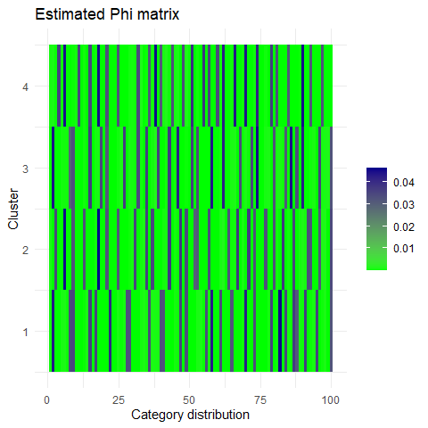

```r
data <- expand.grid(X=1:ncol(sim_data$y), Y=1:4)
data$proportion <- as.vector(phi)

ggplot(data, aes(X, Y, fill= proportion)) + geom_tile() +
  scale_fill_gradient(low="green", high="darkblue",na.value="green") +
  labs(x = "Category distribution") + labs(y = "Cluster") +
  labs(fill = " ")+theme_minimal()+
  ggtitle("Estimated Phi matrix")
```

In many situations, it may be useful to identify the main cluster categories (i.e., main words for each topic or the main species in each community). We define a category to be relevant for a given cluster if it appears at least twice more frequently in the focus cluster than in any other cluster. We use the following code to help us in this task:

```r
phi.max=matrix(NA,nrow=4,ncol=ncol(sim_data$y))
for (i in 1:4){phi.max[i,]=apply(phi[-i,], 2, max)}
results=phi/phi.max
colnames(results)=colnames(phi)
rownames(results)=rownames(phi)
head(round(results[,1:10],2))
```

```
#>          Category1 Category2 Category3 Category4 Category5 Category6 Category7
#> Cluster1      0.01      0.02  13425.28      0.01   5083.02      0.00      0.02
#> Cluster2     87.16      0.03      0.00      0.02      0.00   9123.29      0.01
#> Cluster3      0.00      0.01      0.00     42.22      0.00      0.00      0.02
#> Cluster4      0.00     36.07      0.00      0.00      0.00      0.00     40.49
#>          Category8 Category9 Category10
#> Cluster1   19237.3      0.02       0.03
#> Cluster2       0.0      0.03       0.02
#> Cluster3       0.0      0.01       0.02
#> Cluster4       0.0     36.50      35.67
```

```r
max_categ_cluster=apply(phi/phi.max, 1, function(x) names(sort(x,decreasing=TRUE)))
head(max_categ_cluster)
```

```
#>      Cluster1     Cluster2     Cluster3     Cluster4
#> [1,] "Category17" "Category73" "Category63" "Category83"
#> [2,] "Category32" "Category6"  "Category46" "Category52"
#> [3,] "Category64" "Category65" "Category95" "Category58"
#> [4,] "Category81" "Category27" "Category89" "Category74"
#> [5,] "Category28" "Category69" "Category54" "Category76"
#> [6,] "Category29" "Category98" "Category47" "Category7"
```

Finally, the posterior mean of the regression coefficients are extracted in the following way:

```r
tmp=colMeans(lda_with_covariates$betas[seq1,])
betas=matrix(tmp,ncol=4)
colnames(betas)=paste0('Cluster',1:4)
rownames(betas)=paste0('Coefficients',1:nrow(betas))
head(round(betas,3))
```

```
#>               Cluster1 Cluster2 Cluster3 Cluster4
#> Coefficients1    2.349    1.958    1.896    1.799
#> Coefficients2   -0.012    0.848   -0.003   -0.003
#> Coefficients3    0.010    0.016    0.015    0.996
#> Coefficients4   -0.022   -0.002    0.922    0.003
#> Coefficients5    0.811   -0.033   -0.033   -0.016
```

We can also examine the posterior distribution of the regression coefficients in the following way:

```r
library(reshape2)
library(ggridges)
number <- 1:length(seq1)
aux1 <- data.frame(number,lda_with_covariates$betas[seq1,])
aux2 <- melt(aux1, id=c("number"))
aux2$variable <- (gsub("X", "", aux2$variable))
```

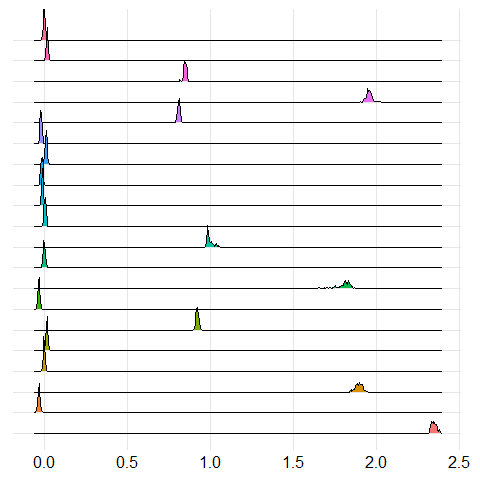

```r
ggplot(aux2, aes(x = value, y = variable, fill = variable)) +
  geom_density_ridges(size=0.4) +
  theme_ridges() +
  theme(legend.position = "none") +
  xlab("Value") +
  ylab("Betas") +
  theme(axis.title.y=element_blank(),
        axis.text.y=element_blank(),
        axis.ticks.y=element_blank(),
        axis.title.x=element_blank())
```

## References

Albuquerque, Pedro HM, Denis Ribeiro do Valle, and Daijiang Li. 2019. “Bayesian Lda for Mixed-Membership Clustering Analysis: The Rlda Package.” *Knowledge-Based Systems* 163: 988–95.

Shimizu, Gilson Yuuji, Rafael Izbicki, and Denis Ribeiro do Valle. 2020. “A New Lda Formulation with Covariates.”